# Predictive Machine Learning Project

Frederico Munoz fsmunoz@gmail.com

25-OCT-2015

# Project Background

Using devices such as Jawbone Up, Nike FuelBand, and Fitbit it is now possible to collect a large amount of data about personal activity relatively inexpensively. These type of devices are part of the quantified self movement – a group of enthusiasts who take measurements about themselves regularly to improve their health, to find patterns in their behavior, or because they are tech geeks. One thing that people regularly do is quantify how much of a particular activity they do, but they rarely quantify how well they do it. In this project, your goal will be to use data from accelerometers on the belt, forearm, arm, and dumbell of 6 participants. They were asked to perform barbell lifts correctly and incorrectly in 5 different ways.

More information is available from the website here: http://groupware.les.inf.puc-rio.br/har (see the section on the Weight Lifting Exercise Dataset). This document uses the DLA dataset that is available there (Ugulino et al. 2012)

# Objective

The goal of your project is to predict the manner in which they did the exercise. This is the “classe” variable in the training set. This document attempts to address this goal.

# Setting up the environment

First, some initial housecleaning involving loading the needed libraries and importing the needed datasets.

```r
## Load used libraries
library(caret)
```

```r
library(rpart)
library(ggplot2)
library(rattle)
library(randomForest)
```

The random seed is set for reproducibly purposes

```r
set.seed(6677)
```

The datasets are available online and so we import them directly.

```r
## Dataset URLs
pml_training_url <- "https://d396qusza40orc.cloudfront.net/predmachlearn/pml-training.csv"
pml_testing_url <- "https://d396qusza40orc.cloudfront.net/predmachlearn/pml-testing.csv"

## Uncomment in the end to avoid fetching at every run
##pml_training<- read.csv(url(pml_training_url),header = T)
##pml_testing<- read.csv(url(pml_testing_url),header = T)

## Assign datasets
pml_testing<- read.csv("pml-testing.csv",header = T)
pml_training <- read.csv("pml-training.csv", header = T)
```

# A quick look

Let us take a quick initial look at the training data we now have available

```r
str(pml_training)
```

```
## 'data.frame':    19622 obs. of  160 variables:
##  $ X                       : int  1 2 3 4 5 6 7 8 9 10 ...
##  $ user_name               : Factor w/ 6 levels "adelmo","carlitos",..: 2 2 2 2 2 2 2 2 2 2 ...
##  $ raw_timestamp_part_1    : int  1323084231 1323084231 1323084231 1323084232 1323084232 1323084232 1323084232 1323084232 1323084232 1323084232 ...
##  $ raw_timestamp_part_2    : int  788290 808298 820366 120339 196328 304277 368296 440390 484323 484434 ...
##  $ cvtd_timestamp          : Factor w/ 20 levels "02/12/2011 13:32",..: 9 9 9 9 9 9 9 9 9 9 ...
##  $ new_window              : Factor w/ 2 levels "no","yes": 1 1 1 1 1 1 1 1 1 1 ...
##  $ num_window              : int  11 11 11 12 12 12 12 12 12 12 ...
##  $ roll_belt               : num  1.41 1.41 1.42 1.48 1.48 1.45 1.42 1.42 1.43 1.45 ...
##  $ pitch_belt              : num  8.07 8.07 8.07 8.05 8.07 8.06 8.09 8.13 8.16 8.17 ...
##  $ yaw_belt                : num  -94.4 -94.4 -94.4 -94.4 -94.4 -94.4 -94.4 -94.4 -94.4 -94.4 ...
##  $ total_accel_belt        : int  3 3 3 3 3 3 3 3 3 3 ...
##  $ kurtosis_roll_belt      : Factor w/ 397 levels "","0.000673",..: 1 1 1 1 1 1 1 1 1 1 ...
##  $ kurtosis_picth_belt     : Factor w/ 317 levels "","0.006078",..: 1 1 1 1 1 1 1 1 1 1 ...
##  $ kurtosis_yaw_belt       : Factor w/ 2 levels "","#DIV/0!": 1 1 1 1 1 1 1 1 1 1 ...
```

[output cut: 86 more lines]

Lots of information there - 19622 observations of 160 variables to be precise. In particular we will focus on the “classe”" (which is Portuguese for “class”) variable which will be the one which we will be predicting.

```r
summary(pml_training$classe)
```

```
##    A    B    C    D    E
## 5580 3797 3422 3216 3607
```

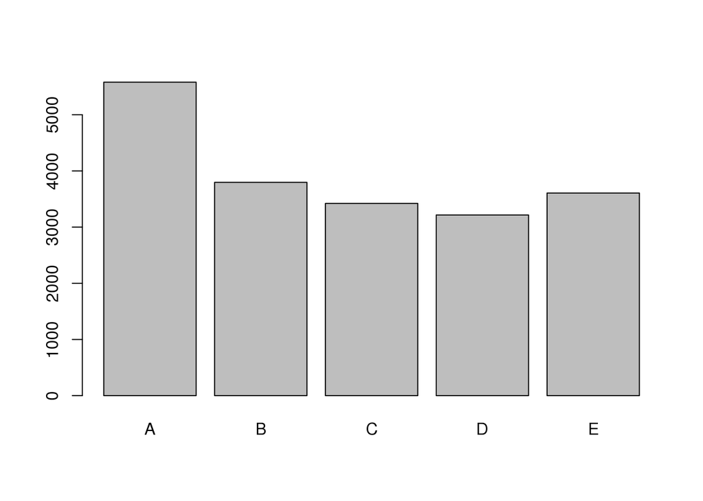

```r
plot(pml_training$classe)
```

# Partitioning the data

We now split the training data into two different sets, training (60%) and testing (40%), using “classe”" as the outcome.

```r
inTrain <- createDataPartition(y=pml_training$classe, p=0.6, list=FALSE)
training_set <- pml_training[inTrain, ]
testing_set <-  pml_training[-inTrain, ]
```

# Cleaning the data

When we took a quick look at the data it was apparent that there were many variables with NA fields. One first approach to improve the quality of the data is to remove variables which are almost always NA (where mostly is determined to be 90%)

```r
var_is_na <- sapply(training_set, function(x) mean(is.na(x))) > 0.9
training_set <- training_set[, var_is_na==F]
str(training_set)
```

```
## 'data.frame':    11776 obs. of  93 variables:
##  $ X                      : int  3 5 8 13 14 16 17 18 20 25 ...
##  $ user_name              : Factor w/ 6 levels "adelmo","carlitos",..: 2 2 2 2 2 2 2 2 2 2 ...
##  $ raw_timestamp_part_1   : int  1323084231 1323084232 1323084232 1323084232 1323084232 1323084232 1323084232 1323084232 1323084232 1323084233 ...
##  $ raw_timestamp_part_2   : int  820366 196328 440390 560359 576390 644302 692324 732306 788335 28311 ...
##  $ cvtd_timestamp         : Factor w/ 20 levels "02/12/2011 13:32",..: 9 9 9 9 9 9 9 9 9 9 ...
##  $ new_window             : Factor w/ 2 levels "no","yes": 1 1 1 1 1 1 1 1 1 1 ...
##  $ num_window             : int  11 12 12 12 12 12 12 12 12 13 ...
##  $ roll_belt              : num  1.42 1.48 1.42 1.42 1.42 1.48 1.51 1.55 1.59 1.53 ...
##  $ pitch_belt             : num  8.07 8.07 8.13 8.2 8.21 8.15 8.12 8.08 8.07 8.11 ...
##  $ yaw_belt               : num  -94.4 -94.4 -94.4 -94.4 -94.4 -94.4 -94.4 -94.4 -94.4 -94.4 ...
##  $ total_accel_belt       : int  3 3 3 3 3 3 3 3 3 3 ...
##  $ kurtosis_roll_belt     : Factor w/ 397 levels "","0.000673",..: 1 1 1 1 1 1 1 1 1 1 ...
##  $ kurtosis_picth_belt    : Factor w/ 317 levels "","0.006078",..: 1 1 1 1 1 1 1 1 1 1 ...
##  $ kurtosis_yaw_belt      : Factor w/ 2 levels "","#DIV/0!": 1 1 1 1 1 1 1 1 1 1 ...
```

[output cut: 79 more lines]

This has reduced the number of variable to 93.

Another step we can take is to remove variables which don’t actually vary that much and as such will not really be useful for predictions[^1]

```r
nzv <- nearZeroVar(training_set)
training_set <- training_set[, -nzv]
```

```r
training_set <- training_set[, -(1:7)]
str(training_set)
```

```
## 'data.frame':    11776 obs. of  52 variables:
##  $ pitch_belt          : num  8.07 8.07 8.13 8.2 8.21 8.15 8.12 8.08 8.07 8.11 ...
##  $ yaw_belt            : num  -94.4 -94.4 -94.4 -94.4 -94.4 -94.4 -94.4 -94.4 -94.4 -94.4 ...
##  $ total_accel_belt    : int  3 3 3 3 3 3 3 3 3 3 ...
##  $ gyros_belt_x        : num  0 0.02 0.02 0.02 0.02 0 0 0 0.02 0.03 ...
##  $ gyros_belt_y        : num  0 0.02 0 0 0 0 0 0.02 0 0 ...
##  $ gyros_belt_z        : num  -0.02 -0.02 -0.02 0 -0.02 0 -0.02 0 -0.02 0 ...
##  $ accel_belt_x        : int  -20 -21 -22 -22 -22 -21 -21 -21 -22 -19 ...
##  $ accel_belt_y        : int  5 2 4 4 4 4 4 5 5 4 ...
##  $ accel_belt_z        : int  23 24 21 21 21 23 22 21 22 21 ...
##  $ magnet_belt_x       : int  -2 -6 -2 -3 -8 0 -6 1 -1 -8 ...
##  $ magnet_belt_y       : int  600 600 603 606 598 592 598 600 604 605 ...
##  $ magnet_belt_z       : int  -305 -302 -313 -309 -310 -305 -317 -316 -314 -319 ...
##  $ roll_arm            : num  -128 -128 -128 -128 -128 -129 -129 -129 -129 -129 ...
##  $ pitch_arm           : num  22.5 22.1 21.8 21.4 21.4 21.3 21.3 21.2 21.1 20.7 ...
```

[output cut: 38 more lines]

… and we’re left with 52 variables.

# Building our model

Armed with a cleaned dataset (or at least cleaner that the one we started with) it’s time to build our model. We have decided on a Random Forest model as a starting point since it seemed appropriate to the task at hand.

```r
## UNCOMMENT TO RUN THE MODEL FROM SCRATCH
##rf_model = train(classe ~ ., method="rf", data=training_set)
## Used once to cache the model, uncomment to overwrite it.
##saveRDS(rf_model, "rfmodel.rds")

## Load the previously saved model
rf_model = readRDS("rfmodel.rds")
```

The model is computed[^2] and we can see the details

```r
rf_model$finalModel
```

```
##
## Call:
##  randomForest(x = x, y = y, mtry = param$mtry)
##                Type of random forest: classification
##                      Number of trees: 500
## No. of variables tried at each split: 26
##
##         OOB estimate of  error rate: 0.94%
## Confusion matrix:
##      A    B    C    D    E class.error
## A 3343    5    0    0    0 0.001493429
## B   26 2236   13    2    2 0.018867925
## C    0   17 2033    4    0 0.010223953
## D    0    1   26 1900    3 0.015544041
## E    0    0    4    8 2153 0.005542725
```

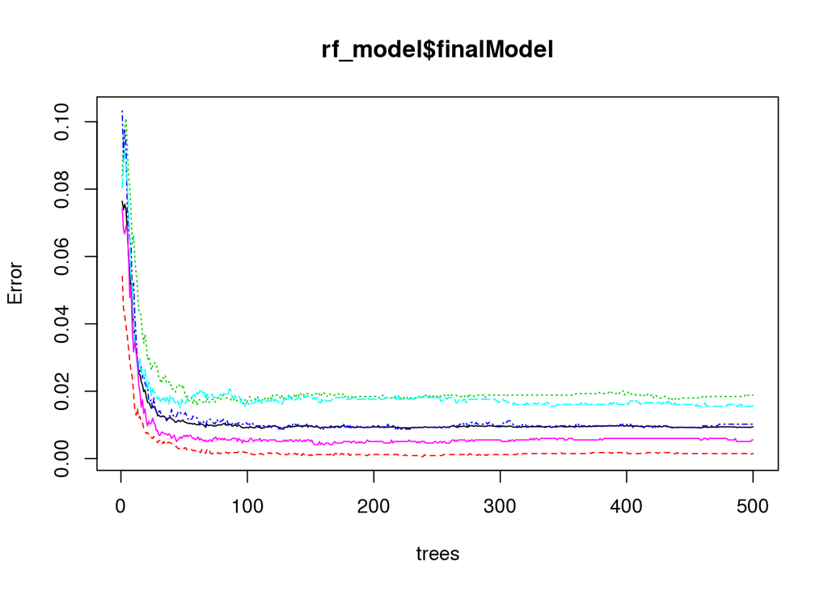

```r
plot(rf_model$finalModel)
```

It chose 500 trees, 26 variables per split and a OOB estimate of error rate of 0.94%.